# Data_Mining_FinalProject (2)

Name - Smeet Kathiria  
Project option number: Option 1

Data Mining Final Project

NJIT id: 31404052

UCID: sbk36

Dataset - https://www.kaggle.com/rakeshrau/social-network-ads?select=Social_Network_Ads.csv

Category 1 - SVM, Category 3- Decision Tree

importing all the required libraries

```python
import pandas as pd
from sklearn.tree import DecisionTreeClassifier, export_graphviz
from sklearn.model_selection import train_test_split,GridSearchCV
from sklearn.preprocessing import StandardScaler
from sklearn.metrics import accuracy_score, confusion_matrix, precision_score, recall_score
from IPython.display import Image
import pydotplus
from sklearn import svm
from sklearn.decomposition import PCA
from sklearn.metrics import plot_confusion_matrix
import numpy as np
from sklearn.model_selection import cross_val_score
import matplotlib.pyplot as plt
```

reading the dataset by calling read_csv function

```python
data = pd.read_csv("Social_Network_Ads.csv")
```

head shows the first five rows in the dataset

```python
data.head()
```

|  | User ID | Gender | Age | EstimatedSalary | Purchased |
| --- | --- | --- | --- | --- | --- |
| 0 | 15624510 | Male | 19 | 19000 | 0 |
| 1 | 15810944 | Male | 35 | 20000 | 0 |
| 2 | 15668575 | Female | 26 | 43000 | 0 |
| 3 | 15603246 | Female | 27 | 57000 | 0 |
| 4 | 15804002 | Male | 19 | 76000 | 0 |

describe gives the Descriptive statistics include those that summarize the central tendency, dispersion and shape of a dataset’s distribution, excluding NaN values.

```python
data.describe()
```

|  | User ID | Age | EstimatedSalary | Purchased |
| --- | --- | --- | --- | --- |
| count | 4.000000e+02 | 400.000000 | 400.000000 | 400.000000 |
| mean | 1.569154e+07 | 37.655000 | 69742.500000 | 0.357500 |
| std | 7.165832e+04 | 10.482877 | 34096.960282 | 0.479864 |
| min | 1.556669e+07 | 18.000000 | 15000.000000 | 0.000000 |
| 25% | 1.562676e+07 | 29.750000 | 43000.000000 | 0.000000 |
| 50% | 1.569434e+07 | 37.000000 | 70000.000000 | 0.000000 |
| 75% | 1.575036e+07 | 46.000000 | 88000.000000 | 1.000000 |
| max | 1.581524e+07 | 60.000000 | 150000.000000 | 1.000000 |

finding the count of male and females

```python
male_sex = len(data[data.Gender == 'Male'].Gender)

female_sex = len(data[data.Gender == 'Female'].Gender)
```

Figuring out the proportions of male and female in the dataset.

[output not shown]

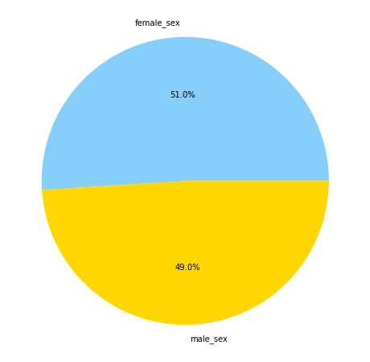

```python
fig = plt.figure(figsize= (8,8) )
pie_plot = fig.add_subplot()
pie_plot.axis('equal')
pie_plot.pie([female_sex, male_sex],labels=['female_sex','male_sex'],autopct='%1.1f%%',colors = ['lightskyblue', 'gold'])
```

checking for null values in the datasets

```python
data.isnull().values.any()
```

```
False
```

one hot encoding categorical values of gender

```python
y = pd.get_dummies(data.Gender, prefix='Gender')
```

```python
y
```

|  | Gender_Female | Gender_Male |
| --- | --- | --- |
| 0 | 0 | 1 |
| 1 | 0 | 1 |
| 2 | 1 | 0 |
| 3 | 1 | 0 |
| 4 | 0 | 1 |
| ... | ... | ... |
| 395 | 1 | 0 |
| 396 | 0 | 1 |
| 397 | 1 | 0 |
| 398 | 0 | 1 |
| 399 | 1 | 0 |

400 rows × 2 columns

```python
data
```

|  | User ID | Gender | Age | EstimatedSalary | Purchased |
| --- | --- | --- | --- | --- | --- |
| 0 | 15624510 | Male | 19 | 19000 | 0 |
| 1 | 15810944 | Male | 35 | 20000 | 0 |
| 2 | 15668575 | Female | 26 | 43000 | 0 |
| 3 | 15603246 | Female | 27 | 57000 | 0 |
| 4 | 15804002 | Male | 19 | 76000 | 0 |
| ... | ... | ... | ... | ... | ... |
| 395 | 15691863 | Female | 46 | 41000 | 1 |
| 396 | 15706071 | Male | 51 | 23000 | 1 |
| 397 | 15654296 | Female | 50 | 20000 | 1 |
| 398 | 15755018 | Male | 36 | 33000 | 0 |
| 399 | 15594041 | Female | 49 | 36000 | 1 |

400 rows × 5 columns

dropping out USER ID and Gender from the data

```python
data = data.drop(columns = ['User ID','Gender'])
```

looking at first 25 rows in the data

```python
data.head(25)
```

|  | Age | EstimatedSalary | Purchased |
| --- | --- | --- | --- |
| 0 | 19 | 19000 | 0 |
| 1 | 35 | 20000 | 0 |
| 2 | 26 | 43000 | 0 |
| 3 | 27 | 57000 | 0 |
| 4 | 19 | 76000 | 0 |
| 5 | 27 | 58000 | 0 |
| 6 | 27 | 84000 | 0 |
| 7 | 32 | 150000 | 1 |
| 8 | 25 | 33000 | 0 |
| 9 | 35 | 65000 | 0 |
| 10 | 26 | 80000 | 0 |
| 11 | 26 | 52000 | 0 |
| 12 | 20 | 86000 | 0 |
| 13 | 32 | 18000 | 0 |
| 14 | 18 | 82000 | 0 |
| 15 | 29 | 80000 | 0 |
| 16 | 47 | 25000 | 1 |
| 17 | 45 | 26000 | 1 |
| 18 | 46 | 28000 | 1 |
| 19 | 48 | 29000 | 1 |
| 20 | 45 | 22000 | 1 |
| 21 | 47 | 49000 | 1 |
| 22 | 48 | 41000 | 1 |
| 23 | 45 | 22000 | 1 |
| 24 | 46 | 23000 | 1 |

creating estimatedsalary variable as numpy array

```python
EstimatedSalary = data['EstimatedSalary'].to_numpy()
```

creating scalar object to apply standard scaling to salary and age variable

```python
scalar = StandardScaler()
```

applying feature scaling to potential columns that we will train our model with. Feature scaling is applied to get all the values in our column in the same scale.

```python
Age = data['Age'].to_numpy()
Age = Age.reshape(-1,1)
Age = scalar.fit_transform(Age)
```

```python
# age_new = scalar.inverse_transform(Age)
```

```python
EstimatedSalary = EstimatedSalary.reshape(-1,1)
EstimatedSalary = scalar.fit_transform(EstimatedSalary)
```

dropping salary from the data and the new modified version with feature scaling will be added later

```python
data.drop(data[['EstimatedSalary']],axis = 1 , inplace= True)
```

here we add the new scaled version back to the data

```python
data['EstimatedSalary'] = EstimatedSalary
```

deleting and adding featured scaled age column to the data

```python
data.drop(data[['Age']],axis = 1 , inplace= True)
```

```python
data['Age'] = Age
```

also adding one hot encoded gender columns to the data

```python
data['Gender_Male'] = y['Gender_Male']
data['Gender_Female'] = y['Gender_Female']
```

now visualizing the statistics of the new data

```python
data.describe()
```

|  | Purchased | EstimatedSalary | Age | Gender_Male | Gender_Female |
| --- | --- | --- | --- | --- | --- |
| count | 400.000000 | 4.000000e+02 | 4.000000e+02 | 400.000000 | 400.000000 |
| mean | 0.357500 | -1.193490e-17 | -2.331468e-16 | 0.490000 | 0.510000 |
| std | 0.479864 | 1.001252e+00 | 1.001252e+00 | 0.500526 | 0.500526 |
| min | 0.000000 | -1.607506e+00 | -1.877311e+00 | 0.000000 | 0.000000 |
| 25% | 0.000000 | -7.852897e-01 | -7.550313e-01 | 0.000000 | 0.000000 |
| 50% | 0.000000 | 7.561451e-03 | -6.256110e-02 | 0.000000 | 1.000000 |
| 75% | 1.000000 | 5.361289e-01 | 7.970571e-01 | 1.000000 | 1.000000 |
| max | 1.000000 | 2.356750e+00 | 2.134241e+00 | 1.000000 | 1.000000 |

sstoring all the column except purchased in X variable

```python
X = data.drop(columns = 'Purchased')
```

```python
X
```

|  | EstimatedSalary | Age | Gender_Male | Gender_Female |
| --- | --- | --- | --- | --- |
| 0 | -1.490046 | -1.781797 | 1 | 0 |
| 1 | -1.460681 | -0.253587 | 1 | 0 |
| 2 | -0.785290 | -1.113206 | 0 | 1 |
| 3 | -0.374182 | -1.017692 | 0 | 1 |
| 4 | 0.183751 | -1.781797 | 1 | 0 |
| ... | ... | ... | ... | ... |
| 395 | -0.844019 | 0.797057 | 0 | 1 |
| 396 | -1.372587 | 1.274623 | 1 | 0 |
| 397 | -1.460681 | 1.179110 | 0 | 1 |
| 398 | -1.078938 | -0.158074 | 1 | 0 |
| 399 | -0.990844 | 1.083596 | 0 | 1 |

400 rows × 4 columns

storing purchased column in y variable

```python
y = data['Purchased']
```

```python
y
```

```
0      0
1      0
2      0
3      0
4      0
      ..
395    1
396    1
397    1
398    0
399    1
Name: Purchased, Length: 400, dtype: int64
```

dong train test split to split the data into four respective variables as shown below, 20% of the data will be used for testing

```python
x_train,x_test,y_train,y_test = train_test_split(X,y,test_size = 0.20, random_state= 97)
```

creating instance of DecisionTreeClassifier and fitting it to the training data

```python
clf = DecisionTreeClassifier()
clf.fit(x_train,y_train)
```

```
DecisionTreeClassifier(ccp_alpha=0.0, class_weight=None, criterion='gini',
                       max_depth=None, max_features=None, max_leaf_nodes=None,
                       min_impurity_decrease=0.0, min_impurity_split=None,
                       min_samples_leaf=1, min_samples_split=2,
                       min_weight_fraction_leaf=0.0, presort='deprecated',
                       random_state=None, splitter='best')
```

now lets take a look at all the feature that are being used for training

```python
feature_name=list(X.columns)
class_name = list(y_train.unique())
feature_name
```

```
['EstimatedSalary', 'Age', 'Gender_Male', 'Gender_Female']
```

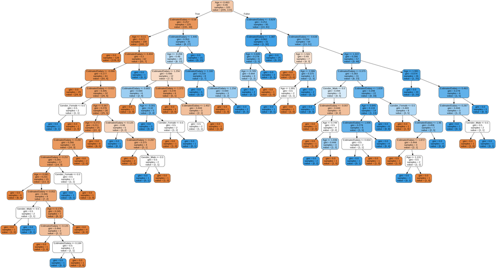

```python
# create a dot_file which stores the tree structure
dot_data = export_graphviz(clf,feature_names = feature_name,rounded = True,filled = True)
# Draw graph
graph = pydotplus.graph_from_dot_data(dot_data)
graph.write_png("myTree.png")
# Show graph
Image(graph.create_png())
```

training score of the classifier

```python
clf.score(x_train,y_train)
```

```
0.996875
```

predicting on test data using predict function

```python
py_pred = clf.predict(x_test)
```

```python
# accuracy of our decision tree classifier without PCA
clf.score(x_test,y_test)
```

```
0.8875
```

Here we print out the mean score of cross validation that we get after applying it on the decision tree classifier. CV= 10 represents 10 fold cross validation

```python
print (cross_val_score(clf, X, y, cv=10, scoring = 'accuracy').mean())
```

```
0.8399999999999999
```

Algorithm - Support Vector Machine

```python
clf = svm.SVC(kernel='linear') # Linear Kernel

#Train the model using the training sets
clf.fit(x_train, y_train)

#Predict the response for test dataset
y_pred = clf.predict(x_test)
```

```python
# accuracy of our SVM classifier without PCA

clf.score(x_test,y_test)
```

```
0.8375
```

```python
print (cross_val_score(clf, X, y, cv=10, scoring = 'accuracy').mean())
```

```
0.8200000000000001
```

10 fold cross validation score comes out to 82% for SVM which is lower than Cross validation score of 84% for Decision tree, this tells us that with new test data Decision tree classifier will perform better.

lets see if we can improve the score using Principal Component Analysis

We will use PCA to find the best no of features for our dataset and use that to train our model

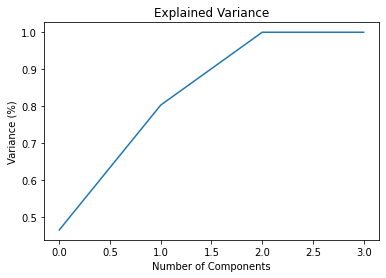

```python
# creating PCA object and using it on data X
pca = PCA()
principalComponents = pca.fit_transform(X)
plt.figure()
plt.plot(np.cumsum(pca.explained_variance_ratio_))
plt.xlabel('Number of Components')
plt.ylabel('Variance (%)') #for each component
plt.title('Explained Variance')
plt.show()
```

```python
# now doing Principal component analysis with just two components
pca = PCA(n_components=2)
# stroing the pca data as new_data which we will than convert to dataframe
new_data = pca.fit_transform(X)

# creating dataframe with two columns PC1 and PC2 for the two PCA features that we get from above
principal_x = pd.DataFrame(new_data,columns=['PC-1','PC-2'])
```

lets see how the principal_x data looks

```python
principal_x
```

|  | PC-1 | PC-2 |
| --- | --- | --- |
| 0 | -2.374887 | -0.210354 |
| 1 | -1.276887 | 0.844897 |
| 2 | -1.266245 | -0.213647 |
| 3 | -0.910307 | -0.438198 |
| 4 | -1.199865 | -1.398427 |
| ... | ... | ... |
| 395 | 0.039258 | 1.173158 |
| 396 | -0.137658 | 1.858461 |
| 397 | -0.124298 | 1.879893 |
| 398 | -0.941563 | 0.641189 |
| 399 | 0.138196 | 1.479143 |

400 rows × 2 columns

lets see how many unique values inside the purchased columns

```python
data['Purchased'].unique()
```

```
array([0, 1])
```

```python
# let's see how well our model perform on this new data
x_train,x_test,y_train,y_test = train_test_split(principal_x,y,test_size = 0.20, random_state= 97)
```

performing same steps again for testing decision tree accuracy with the feature engineered data

```python
clf = DecisionTreeClassifier()
clf.fit(x_train,y_train)
# accuracy of our decision tree classifier with PCA

clf.score(x_test,y_test)
```

```
0.8875
```

Our accuracy remains same after performing PCA for Decision tree, lets try grid search techhnique to see if it can be optimized

Now lets try to hypertune the parameters using gridsearch algorithm

these are the estimated hyperparameters that are being used, gridsearch will test each parameter value one by one and give us the best possible value to use inside our model

```python
grid_param = {
    'criterion': ['gini', 'entropy'],
    'max_depth' : range(2,32,1),
    'min_samples_leaf' : range(1,10,1),
    'min_samples_split': range(2,10,1),
    'splitter' : ['best', 'random']

}
```

```python
grid_search = GridSearchCV(estimator= clf,
                     param_grid=grid_param,
                     cv=10,
                    n_jobs = -1)
```

fitting the training data on grid search to get the best hyper parameters

```python
grid_search.fit(x_train,y_train)
```

```
GridSearchCV(cv=10, error_score=nan,
             estimator=DecisionTreeClassifier(ccp_alpha=0.0, class_weight=None,
                                              criterion='gini', max_depth=None,
                                              max_features=None,
                                              max_leaf_nodes=None,
                                              min_impurity_decrease=0.0,
                                              min_impurity_split=None,
                                              min_samples_leaf=1,
                                              min_samples_split=2,
                                              min_weight_fraction_leaf=0.0,
                                              presort='deprecated',
                                              random_state=None,
                                              splitter='best'),
             iid='deprecated', n_jobs=-1,
             param_grid={'criterion': ['gini', 'entropy'],
                         'max_depth': range(2, 32),
                         'min_samples_leaf': range(1, 10),
                         'min_samples_split': range(2, 10),
                         'splitter': ['best', 'random']},
             pre_dispatch='2*n_jobs', refit=True, return_train_score=False,
             scoring=None, verbose=0)
```

here we print out the best hyper parameters

```python
best_parameters = grid_search.best_params_
print(best_parameters)
```

```
{'criterion': 'gini', 'max_depth': 15, 'min_samples_leaf': 3, 'min_samples_split': 7, 'splitter': 'random'}
```

```python
grid_search.best_score_
```

```
0.909375
```

# we use grid search method to find the best parameters for our model and to make a more generalized model that does not show overfitting

```python
clf = DecisionTreeClassifier(criterion = 'gini',max_depth = 15, min_samples_leaf= 3, min_samples_split= 7, splitter ='random')
clf.fit(x_train,y_train)
```

```
DecisionTreeClassifier(ccp_alpha=0.0, class_weight=None, criterion='gini',
                       max_depth=15, max_features=None, max_leaf_nodes=None,
                       min_impurity_decrease=0.0, min_impurity_split=None,
                       min_samples_leaf=3, min_samples_split=7,
                       min_weight_fraction_leaf=0.0, presort='deprecated',
                       random_state=None, splitter='random')
```

```python
y_pred = clf.predict(x_test)
```

```python
clf.score(x_test,y_test)
```

```
0.8875
```

We can see above that after using grid search approach our accuracy has remained the same which is 88.75% but we have now build a more generalized model which prevents overfitting.

Now lets try to visualize the new decison tree

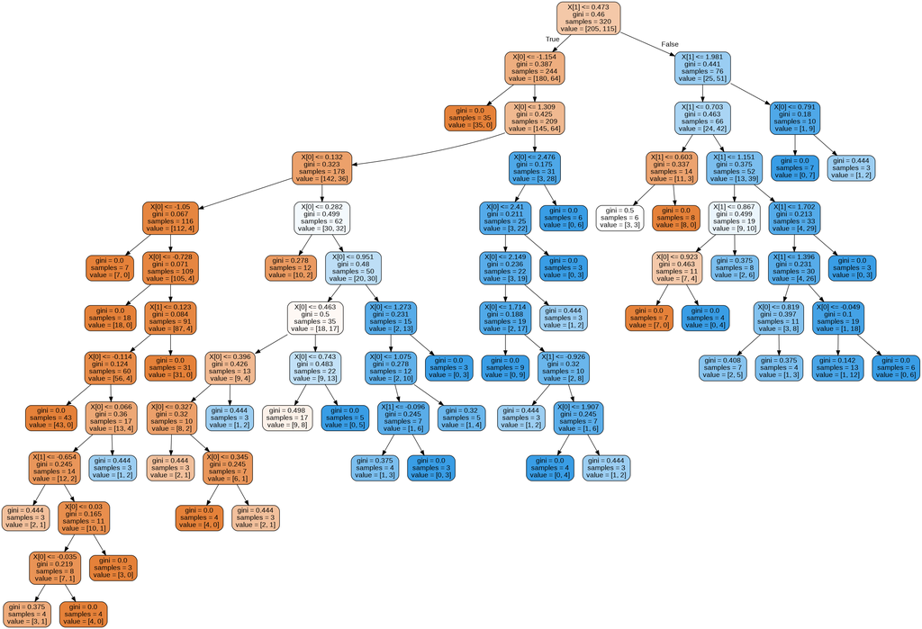

```python
feature_name=list(X.columns)
class_name = list(y_train.unique())
# create a dot_file which stores the tree structure
dot_data = export_graphviz(clf,rounded = True,filled = True)
# Draw graph
graph = pydotplus.graph_from_dot_data(dot_data)
#graph.write_png("tree.png")
# Show graph
Image(graph.create_png())
```

Creating confusion matrix to see how better our model is at evaluating test data

```python
cm = confusion_matrix(y_test, y_pred)
```

Visualizing confusion matrix with and without normalization

```
Confusion matrix, without normalization
[[48  4]
 [ 5 23]]
Normalized confusion matrix
[[0.92307692 0.07692308]
 [0.17857143 0.82142857]]
```

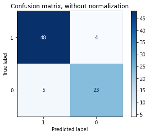

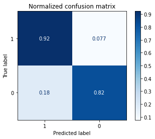

```python
titles_options = [("Confusion matrix, without normalization", None),
                  ("Normalized confusion matrix", 'true')]
for title, normalize in titles_options:
    disp = plot_confusion_matrix(clf, x_test, y_test,
                                 display_labels= class_name,
                                 cmap=plt.cm.Blues,
                                 normalize=normalize)
    disp.ax_.set_title(title)

    print(title)
    print(disp.confusion_matrix)

plt.show()
```

Type 2 error shows 5 wrong outcomes which I think can be reduced by using deep learing techniques and using large datasets for model training.

Alogrithm 2- Support Vector **Machine**

lets check if the accuracy increases for SVM with PCA data

```python
clf = svm.SVC(kernel='linear') # Linear Kernel

#Train the model using the training sets
clf.fit(x_train, y_train)

#Predict the response for test dataset
y_pred = clf.predict(x_test)
```

```python
# accuracy of our decision tree classifier with PCA
clf.score(x_test,y_test)
```

```
0.8375
```

```python
print("Accuracy:",accuracy_score(y_test, y_pred))
```

```
Accuracy: 0.8375
```

```python
print("Precision:",precision_score(y_test, y_pred))
print("Recall:",recall_score(y_test, y_pred))
```

```
Precision: 0.8571428571428571
Recall: 0.6428571428571429
```

```
Confusion matrix, without normalization
[[49  3]
 [10 18]]
Normalized confusion matrix
[[0.94230769 0.05769231]
 [0.35714286 0.64285714]]
```

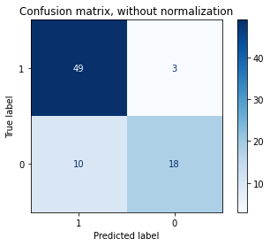

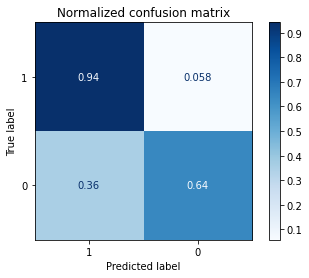

```python
titles_options = [("Confusion matrix, without normalization", None),
                  ("Normalized confusion matrix", 'true')]
for title, normalize in titles_options:
    disp = plot_confusion_matrix(clf, x_test, y_test,
                                 display_labels= class_name,
                                 cmap=plt.cm.Blues,
                                 normalize=normalize)
    disp.ax_.set_title(title)

    print(title)
    print(disp.confusion_matrix)

plt.show()
```

From above matrix, Type 2 error shows 10 wrong outcome, where as there are three false positives.

Lets try to increase the accuracy using gridsearchCV for SVM classifier

```python
param_grid={'C':[0.1,1,10,50,100,500],'gamma':[1,0.5,0.1,0.01,0.001]}
```

```python
grid= GridSearchCV(svm.SVC(),param_grid, verbose=3, n_jobs=-1)
```

```python
grid.fit(x_train,y_train)
```

```
Fitting 5 folds for each of 30 candidates, totalling 150 fits
```

```
[Parallel(n_jobs=-1)]: Using backend LokyBackend with 2 concurrent workers.
[Parallel(n_jobs=-1)]: Done  72 tasks      | elapsed:    1.6s
[Parallel(n_jobs=-1)]: Done 150 out of 150 | elapsed:    2.1s finished
```

```
GridSearchCV(cv=None, error_score=nan,
             estimator=SVC(C=1.0, break_ties=False, cache_size=200,
                           class_weight=None, coef0=0.0,
                           decision_function_shape='ovr', degree=3,
                           gamma='scale', kernel='rbf', max_iter=-1,
                           probability=False, random_state=None, shrinking=True,
                           tol=0.001, verbose=False),
             iid='deprecated', n_jobs=-1,
             param_grid={'C': [0.1, 1, 10, 50, 100, 500],
                         'gamma': [1, 0.5, 0.1, 0.01, 0.001]},
             pre_dispatch='2*n_jobs', refit=True, return_train_score=False,
             scoring=None, verbose=3)
```

```python
grid.best_params_
```

```
{'C': 0.1, 'gamma': 0.5}
```

gamma: Kernel coefficient for ‘rbf’, ‘poly’ and ‘sigmoid’ C : Regularization Parameter

```python
clf=svm.SVC(C=0.1, gamma=0.5)
clf.fit(x_train,y_train)
```

```
SVC(C=0.1, break_ties=False, cache_size=200, class_weight=None, coef0=0.0,
    decision_function_shape='ovr', degree=3, gamma=0.5, kernel='rbf',
    max_iter=-1, probability=False, random_state=None, shrinking=True,
    tol=0.001, verbose=False)
```

```
Confusion matrix, without normalization
[[48  4]
 [ 4 24]]
Normalized confusion matrix
[[0.92307692 0.07692308]
 [0.14285714 0.85714286]]
```

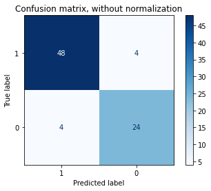

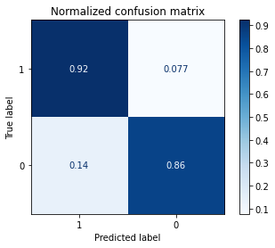

```python
titles_options = [("Confusion matrix, without normalization", None),
                  ("Normalized confusion matrix", 'true')]
for title, normalize in titles_options:
    disp = plot_confusion_matrix(clf, x_test, y_test,
                                 display_labels= class_name,
                                 cmap=plt.cm.Blues,
                                 normalize=normalize)
    disp.ax_.set_title(title)

    print(title)
    print(disp.confusion_matrix)

plt.show()
```

```python
print("Accuracy:",accuracy_score(y_test, y_pred))
```

```
Accuracy: 0.8375
```

```python
print("Precision:",precision_score(y_test, y_pred))

print("Recall:",recall_score(y_test, y_pred))
```

```
Precision: 0.8571428571428571
Recall: 0.6428571428571429
```